### Create a histogram of the total number of steps taken each day

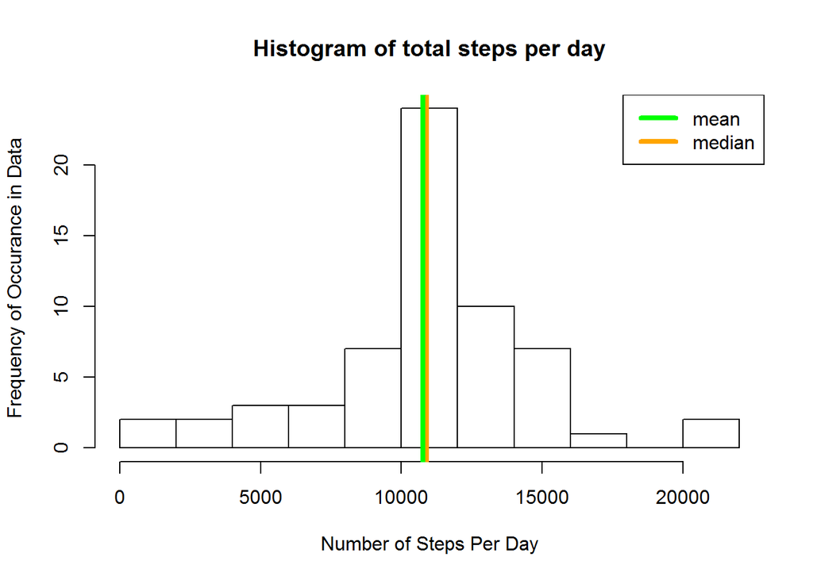

```r
hist(totalSteps2, breaks = 12,
     xlab = "Number of Steps Per Day",
     ylab = "Frequency of Occurance in Data",
     main = "Histogram of total steps per day")

abline(v=stepMean2, col="green", lwd ="5")
abline(v=stepMedian2, col="orange", lwd ="3")
legend(x = "topright", legend = c("mean", "median"), col=c("green","orange"), lwd = 4)
```

Since we injected the mean many times over into the new data, the mean is now the most common entry, and dominates the median, skewing that particular metric. Aside from that, the data does look to be smoothed out in some places. It looks like the overall variance and standard deviation has decreased, with the first sigma falling in a much narrower range than previously observed.

## Are there differences in activity patterns between weekdays and weekends?

```r
newData$Weekend <- weekdays(newData$Date) == "Saturday" | weekdays(newData$Date) == "Sunday"

newData$Weekend <- factor(newData$Weekend, levels = c(F, T), labels = c("Weekday", "Weekend"))

activity <- ddply(newData, .(Interval, Weekend), summarize, steps = mean(Steps, na.rm = TRUE))

library(lattice)
```

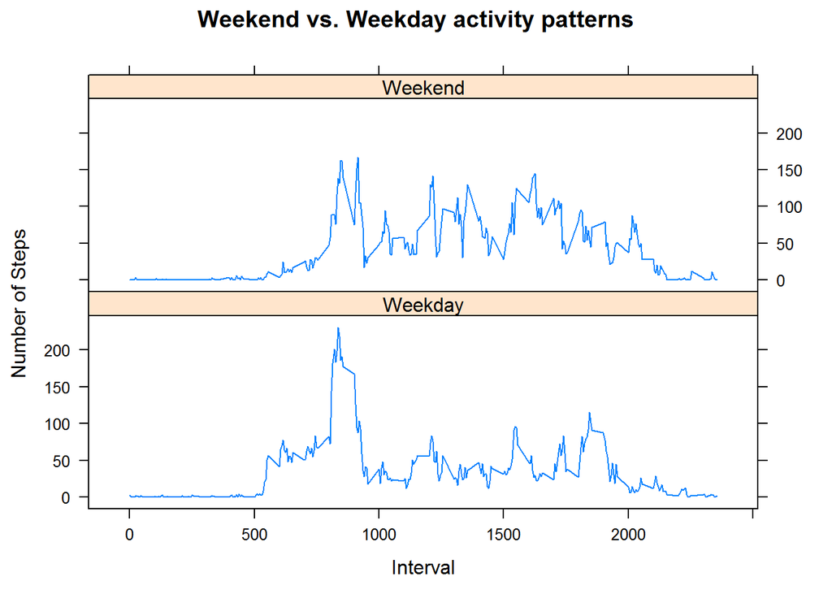

```r
xyplot(steps ~ Interval | Weekend, activity, type = "l", layout = c(1, 2), ylab = "Number of Steps", xlab = "Interval", main = "Weekend vs. Weekday activity patterns")
```

It looks like the activity is different on weekends. Both series show a burst early in the day, however on weekdays the activity dies down at 10 AM. This effect is much less pronounced on weekends, where activity seems to be more evenly spread throughout the day.